[Présentation](https://ngartiexauce.github.io/fproject/index.html) [Statistiques descriptives](https://ngartiexauce.github.io/fproject/stats_desc.html) [Profils des équipes](https://ngartiexauce.github.io/fproject/profil.html) [Prédiction du classement final](https://ngartiexauce.github.io/fproject/classement.html) [Prédiction de valeurs marchandes](https://ngartiexauce.github.io/fproject/valeur.html) [Comparaison des championnats](https://ngartiexauce.github.io/fproject/comparaison.html)

# Projet Football

Luweh Adjim Ngarti Exaucé & Laamoumri Yassine

01/02/2022

Jusqu’à présent nous avons tenté d’expliquer le positionnement au classement final par les statistiques durant les matchs. Ce travail reste très intéressant car en fonction de cela on peut avoir une idée sur la stratégie technique optimale. Toutefois ces sont globalement connues par les acteurs du domaine. Le défi face auquel font face les équipe concerne le profil type de joueurs à recruter. Donc la suite nous allons essayer de prédire la valeur marchande d’un joueur en fonction de ses statistiques.

## Prédire la valeur marchande des joueurs

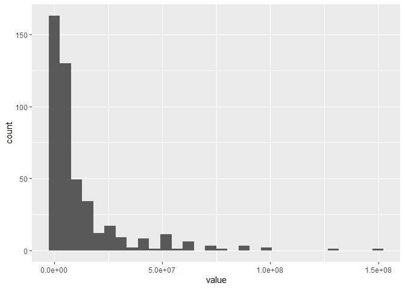

On sépare les variables quantitatives des variables qualitatives

Nous allons dans une première partie utilsé uniquement les variables quantitatives afin de prédire par des méthodes de régression linéaire ou non lineaire ensuite nous allons ajouter les variables qualitatives afin d’améliorer le modèle.

### Utilisation de variable quantitative

#### Réduction de dimension

##### ACP

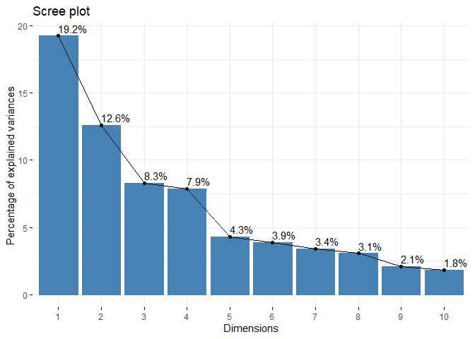

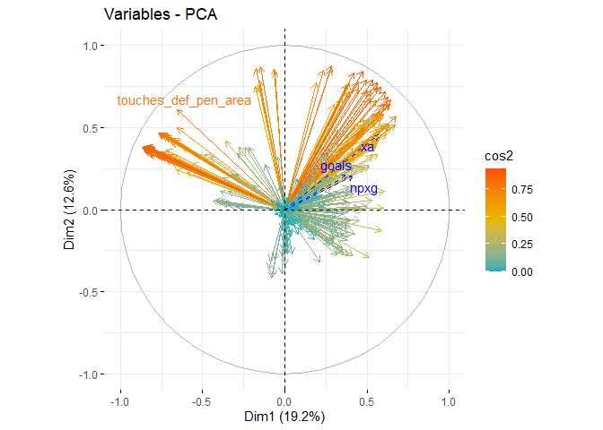

L’ACP parait pas très pertinente mais en réalité en prenant les 50 premières dimensions, on peut passer de $\mathbb{R}^{390}$ à $\mathbb{R}^{50}$ tout en captant un peu plus de 90% de la variabilité.

##### Réduction par seuil de corrélation

Les résultats de l’ACP laisse supposer une forte corrélation des variables. Nous allons réduire la dimension en fixant un seuil de corrélation linéaire.

Avec un seuil de corrélation de $0,9$, on posse de $\mathbb{R}^{390}$ à $\mathbb{R}^{212}$

Nous allons prédire les valeurs en se servant des deux méthodes de réduction de dimension, ACP et seuil de corrélation.

### Prédiction

#### ACP + Regression linéaire

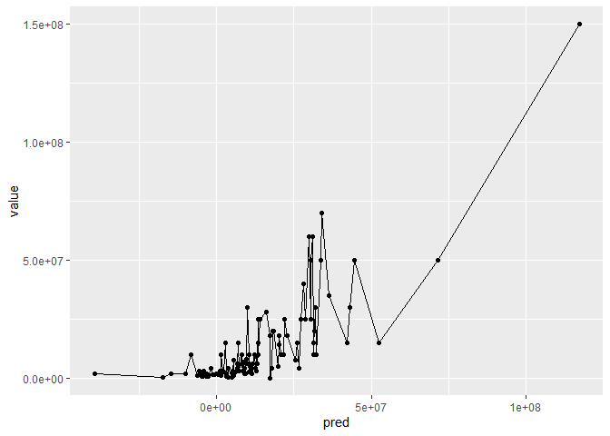

Le résultat n’est pas très convaincant, nous allons effectuer des méthodes de regression avec réduction de dimension et pénalisation.

### Regression PCR,PLS et sPLS

#### Seuil puis regression linéaire

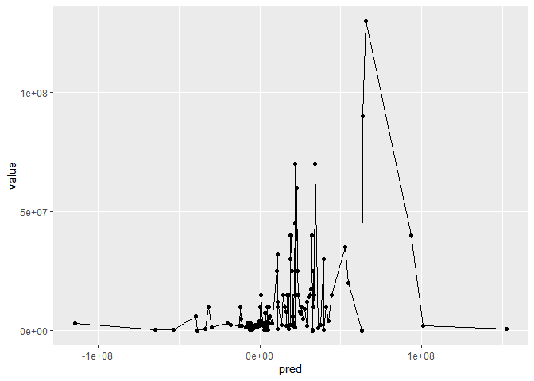

### Réseau de neurones

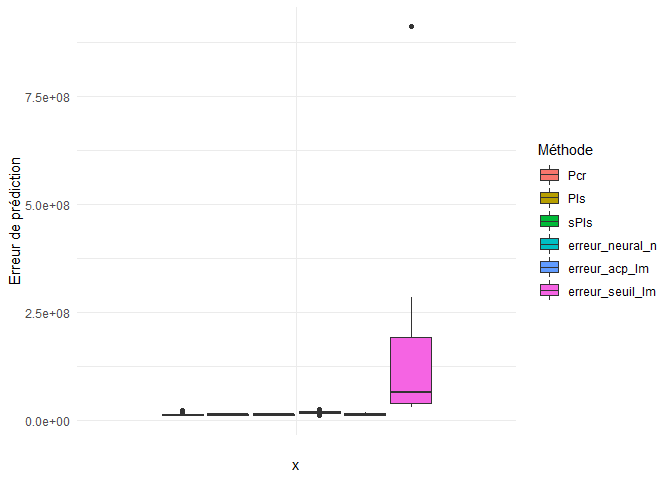

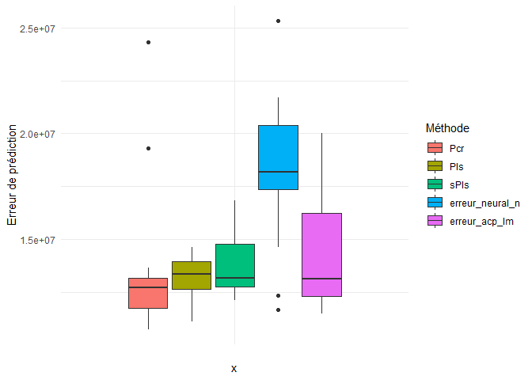